# Assignment 5

Jiahao Chen

2021/11/28

# Data Preparation

```r
library(cluster)
library(tidyverse)
library(factoextra)
library(caret)
```

```r
library(dplyr)
library(ggplot2)
data.pro<-read.csv("Cereals.csv")
data.pro<-na.omit(data.pro)
data.pro$name<-as.factor(data.pro$name)
data.pro$mfr<-as.factor(data.pro$mfr)
data.pro$type<-as.factor(data.pro$type)
summary(data.pro)
```

```
##                         name    mfr    type      calories      protein
##  100%_Bran                : 1   A: 1   C:73   Min.   : 50   Min.   :1.000
##  100%_Natural_Bran        : 1   G:22   H: 1   1st Qu.:100   1st Qu.:2.000
##  All-Bran                 : 1   K:23          Median :110   Median :2.500
##  All-Bran_with_Extra_Fiber: 1   N: 5          Mean   :107   Mean   :2.514
##  Apple_Cinnamon_Cheerios  : 1   P: 9          3rd Qu.:110   3rd Qu.:3.000
##  Apple_Jacks              : 1   Q: 7          Max.   :160   Max.   :6.000
##  (Other)                  :68   R: 7
##       fat        sodium          fiber            carbo           sugars
##  Min.   :0   Min.   :  0.0   Min.   : 0.000   Min.   : 5.00   Min.   : 0.000
##  1st Qu.:0   1st Qu.:135.0   1st Qu.: 0.250   1st Qu.:12.00   1st Qu.: 3.000
##  Median :1   Median :180.0   Median : 2.000   Median :14.50   Median : 7.000
##  Mean   :1   Mean   :162.4   Mean   : 2.176   Mean   :14.73   Mean   : 7.108
##  3rd Qu.:1   3rd Qu.:217.5   3rd Qu.: 3.000   3rd Qu.:17.00   3rd Qu.:11.000
##  Max.   :5   Max.   :320.0   Max.   :14.000   Max.   :23.00   Max.   :15.000
##
##      potass          vitamins          shelf           weight
##  Min.   : 15.00   Min.   :  0.00   Min.   :1.000   Min.   :0.500
##  1st Qu.: 41.25   1st Qu.: 25.00   1st Qu.:1.250   1st Qu.:1.000
##  Median : 90.00   Median : 25.00   Median :2.000   Median :1.000
##  Mean   : 98.51   Mean   : 29.05   Mean   :2.216   Mean   :1.031
##  3rd Qu.:120.00   3rd Qu.: 25.00   3rd Qu.:3.000   3rd Qu.:1.000
##  Max.   :330.00   Max.   :100.00   Max.   :3.000   Max.   :1.500
##
##       cups            rating
##  Min.   :0.2500   Min.   :18.04
##  1st Qu.:0.6700   1st Qu.:32.45
##  Median :0.7500   Median :40.25
##  Mean   :0.8216   Mean   :42.37
##  3rd Qu.:1.0000   3rd Qu.:50.52
##  Max.   :1.5000   Max.   :93.70
##
```

In the output, the majority of breakfast manufacturers are G and K. Almost breakfast type is C.

# Normalize the numerical variables

```r
data.pro_norm<-data.pro
data.pro_norm[,c(4:16)]<-scale(data.pro[,c(4:16)])
head(data.pro_norm)
```

```
##                        name mfr type   calories    protein        fat
## 1                 100%_Bran   N    C -1.8659155  1.3817478  0.0000000
## 2         100%_Natural_Bran   Q    C  0.6537514  0.4522084  3.9728810
## 3                  All-Bran   K    C -1.8659155  1.3817478  0.0000000
## 4 All-Bran_with_Extra_Fiber   K    C -2.8737823  1.3817478 -0.9932203
## 6   Apple_Cinnamon_Cheerios   G    C  0.1498180 -0.4773310  0.9932203
## 7               Apple_Jacks   K    C  0.1498180 -0.4773310 -0.9932203
##       sodium       fiber      carbo     sugars     potass   vitamins      shelf
## 1 -0.3910227  3.22866747 -2.5001396 -0.2542051  2.5605229 -0.1818422  0.9419715
## 2 -1.7804186 -0.07249167 -1.7292632  0.2046041  0.5147738 -1.3032024  0.9419715
## 3  1.1795987  2.81602258 -1.9862220 -0.4836096  3.1248675 -0.1818422  0.9419715
## 4 -0.2702057  4.87924705 -1.7292632 -1.6306324  3.2659536 -0.1818422  0.9419715
## 6  0.2130625 -0.27881412 -1.0868662  0.6634132 -0.4022862 -0.1818422 -1.4616799
## 7 -0.4514312 -0.48513656 -0.9583868  1.5810314 -0.9666308 -0.1818422 -0.2598542
##       weight       cups     rating
## 1 -0.2008324 -2.0856582  1.8549038
## 2 -0.2008324  0.7567534 -0.5977113
## 3 -0.2008324 -2.0856582  1.2151965
## 4 -0.2008324 -1.3644493  3.6578436
## 6 -0.2008324 -0.3038480 -0.9165248
## 7 -0.2008324  0.7567534 -0.6553998
```

# Hierarchical Clustering with Agnes

We need to choose the higher value for strong clustering structure.

```r
hc_single<-agnes(data.pro_norm[,c(4:16)],method = "single")
hc_complete<-agnes(data.pro_norm[,c(4:16)],method = "complete")
hc_averages<-agnes(data.pro_norm[,c(4:16)],method = "average")
hc_ward<-agnes(data.pro_norm[,c(4:16)],method = "ward")
```

## Compared Agglomerative coefficients

```r
print(hc_single$ac)
```

```
## [1] 0.6067859
```

```r
print(hc_complete$ac)
```

```
## [1] 0.8353712
```

```r
print(hc_averages$ac)
```

```
## [1] 0.7766075
```

```r
print(hc_ward$ac)
```

```
## [1] 0.9046042
```

Best link method is Ward.

# Choose number of cluster

## Using elbow and silhouette method

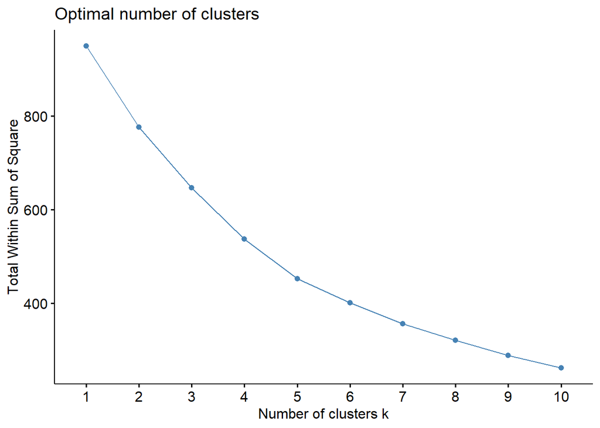

```r
fviz_nbclust(data.pro_norm[,c(4:16)],hcut,method = "wss")
```

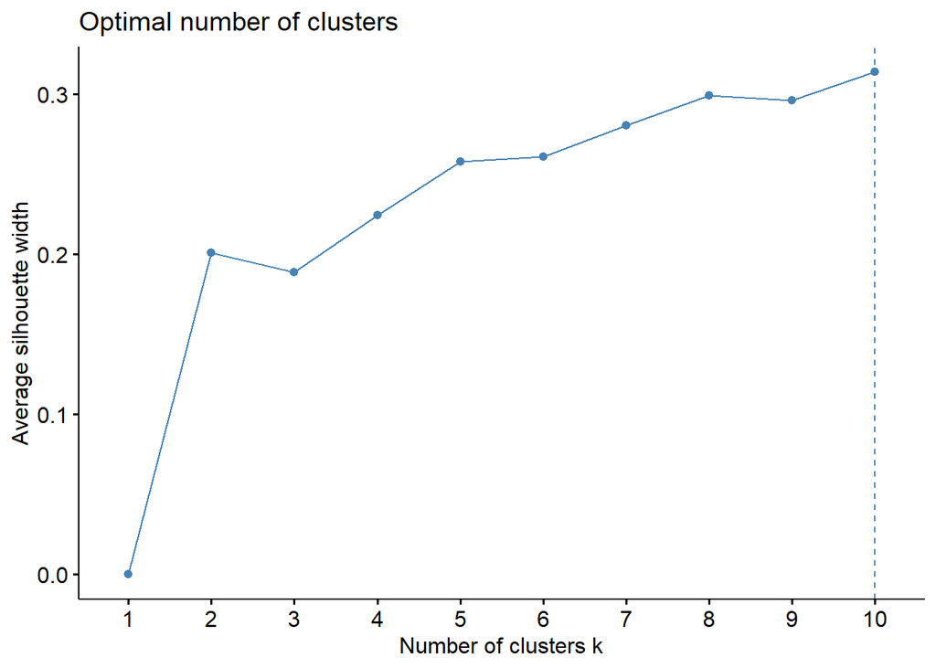

```r
fviz_nbclust(data.pro_norm[,c(4:16)],hcut,method = "silhouette")
```

Form silhouette method, the value of K is 10. But we might combine with the original data and decision tree analysis.

## Cutting Dendrograms

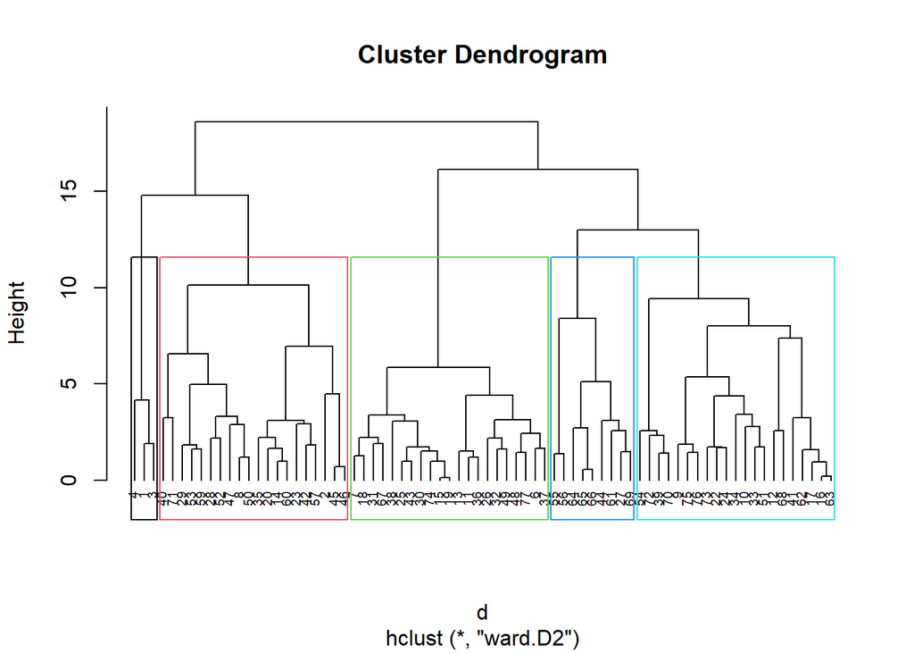

```r
d<-dist(data.pro_norm[,c(4:16)],method = "euclidean")
hw<-hclust(d,method = "ward.D2")
plot(hw,cex=0.6,hang = -1)
rect.hclust(hw,k=5,border=1:5)
```

From the original data and cutting Dendrogram graph, I would like to choose that value of Cluster equals to 5. They have moderate similarity and sufficient sample size in their respective categories, and will not produce two overly similar categories due to too much detail.

## visual the clusters

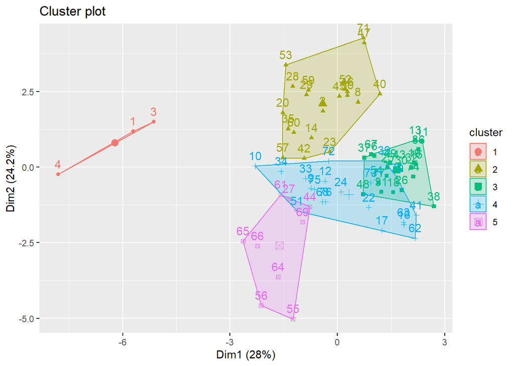

```r
cl<-cutree(hw,k=5)
data.pro_norm$cl<-cl
data.pro_norm$cl<-as.factor(data.pro_norm$cl)
fviz_cluster(list(data=data.pro_norm[,c(4:16)],cluster=cl))
```

As you can see from the diagram, there is still a small amount of overlap in the clusters.

# Cluster Stability

```r
set.seed(150)
Index<-createDataPartition(data.pro_norm$calories,p=0.6,list = F) #Divide the data into 60% and 40%
acdata<-data.pro_norm[Index,]
padata<-data.pro_norm[-Index,]
hc_single<-agnes(acdata[,c(4:16)],method = "single")
hc_complete<-agnes(acdata[,c(4:16)],method = "complete")
hc_averages<-agnes(acdata[,c(4:16)],method = "average")
hc_ward<-agnes(acdata[,c(4:16)],method = "ward")
```

```r
print(hc_single$ac)
```

```
## [1] 0.580269
```

```r
print(hc_complete$ac)
```

```
## [1] 0.8124025
```

```r
print(hc_averages$ac)
```

```
## [1] 0.7622624
```

```r
print(hc_ward$ac)
```

```
## [1] 0.8638271
```

The best linkage method is Ward.

## Cluster from acdata

Assuming that the value of k is equal to the all data.

```r
d<-dist(acdata[,c(4:16)],method = "euclidean")
hw<-hclust(d,method = "ward.D2")
cl1<-cutree(hw,k=5)
table(cl1)
```

```
## cl1
##  1  2  3  4  5
##  2  9  9 14 11
```

```r
acdata$cl1<-cl1
```

## Cluster centroid in acdata

```r
acdatacl1<-summarise(group_by(acdata,cl1),calories=mean(calories),protein=mean(protein),fat=mean(fat),sodium=mean(sodium),fiber=mean(fiber),carbo=mean(carbo),sugars=mean(sugars),potass=mean(potass),vitamins=mean(vitamins),shelf=mean(shelf),weight=mean(weight),cups=mean(cups),rating=mean(rating))
ac<-matrix(nrow = 29,ncol = 5 )
cl2<-matrix(nrow=29,ncol = 1)
```

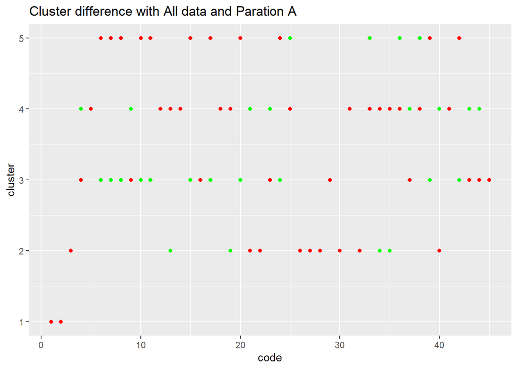

```r
for(i in 1:29){
  for(j in 1:5){
   ab<-rbind(padata[i,c(4:16)],acdatacl1[j,c(2:14)])
   ac[i,j]<-dist(ab,method = "euclidean")

  }
}
colnames<-c("1","2","3","4","5")
colnames(ac)<-colnames
ac<-as.data.frame(ac)



for(i in 1:29){
  cl2[i,1]<-which.min(ac[i,])
}
padata<-cbind(padata,cl2)
acdata$cl<-as.numeric(acdata$cl)
acdata$code<-c(1:45)
padata$cl<-as.numeric(padata$cl)
padata$code<-c(1:29)
ggplot(acdata,aes(x=acdata$code,y=acdata$cl))+geom_point(color="green")+geom_point(y=acdata$cl1,color="red")+xlab("code")+ylab("cluster")+ggtitle("Cluster difference with All data and Paration A")
```

In these graph, many records are divided into different clusters.

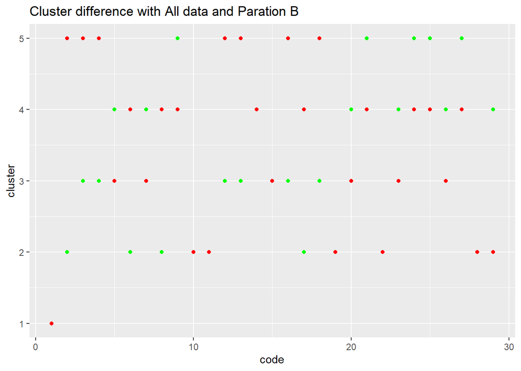

```r
ggplot(padata,aes(x=code,y=cl))+geom_point(color="green")+geom_point(y=cl2,color="red")+xlab("code")+ylab("cluster")+ggtitle("Cluster difference with All data and Paration B")
```

In these two graph, there are so many records that have different clusters. So the cluster stability is very low.

# Recommendation of Healthy Food

For the healthy food, I think we should find the breakfast that have the high protein and fiber,low sugar and sodium. The data normalization is used to establish the model without scale affection. But we use non-normalized data to make recommendations. So I also use 5 clusters.

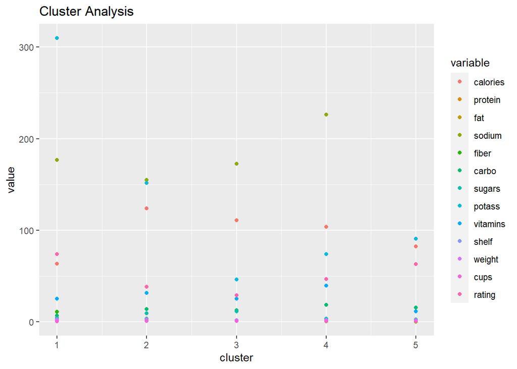

```r
data.pro$cl<-cl
data.pro1<-summarise(group_by(data.pro,cl),calories=mean(calories),protein=mean(protein),fat=mean(fat),sodium=mean(sodium),fiber=mean(fiber),carbo=mean(carbo),sugars=mean(sugars),potass=mean(potass),vitamins=mean(vitamins),shelf=mean(shelf),weight=mean(weight),cups=mean(cups),rating=mean(rating))
mdf<-reshape2::melt(data.pro1,id.var="cl")
ggplot(mdf,aes(x=cl,y=value,color=variable))+geom_point()+xlab("cluster")+ggtitle("Cluster Analysis")
```

From Cluster Analysis, the food in cluster 5 have less sodium and the other ingredient are similar. So I choose the food in cluster 5 for recommendation.

```r
row.names(data.pro) <- data.pro[,1]
rownames(data.pro)[cl==5]
```

```
## [1] "Frosted_Mini-Wheats"       "Maypo"
## [3] "Puffed_Rice"               "Puffed_Wheat"
## [5] "Raisin_Squares"            "Shredded_Wheat"
## [7] "Shredded_Wheat_'n'Bran"    "Shredded_Wheat_spoon_size"
## [9] "Strawberry_Fruit_Wheats"
```

The name of these items are Frosted_Mini-Wheats, Maypo, Puffed_Rice, Puffed_Wheat, Raisin_Squares, Shredded_Wheat, Shredded_Wheat_’n’Bran, Shredded_Wheat_spoon_size and Strawberry_Fruit_Wheats.